# Classifying "Happy" Songs

## *An Analysis of Spotify Track Information*

### Eric Ropeta - 12/3/2019

#### **1. Background and Motivations**

Before taking a walk one day, I was struggling to decide what kind of music I wanted to listen to. This caused me to look through Spotify's feature that allows users to listen to music that falls within a specific "mood" category. While looking through the different "moods" I could choose from, I asked myself some questions: 1. Do other qualities of songs, like energy, tempo, etc., coincide with how "Happy" a song is? 2. Do different genres fall into one "mood" category more than another? 3. Is there any correlation between the population of certain genres and how "Happy" it is? After my walk, I did some research on the Spotify for Developers website. I found that they use a term called "valence" to describe how positive a song is, and it is based on a scale from 0.0 to 1.0.<sub>1.</sub> Then, I set out to find correlations between valence and other attributes of Spotify tracks so I can find an answer to my questions.

#### **2. Methodology**

This study relies on a single dataset that was produced by Zaheen Hamidani and published for public use on Kaggle.com.<sub>2</sub> In the beginning, I imported the dataset using Pandas and separated it into 26 smaller, more manageable datasets for each of the 26 genres of music in the dataset. To analyze the quantifiable data, I used two-dimensional histograms that allowed me to view the density of the datapoints in certain areas throughout the plot. For categorical data, I used violin plots to, again, more accurately see the density of the data in different parts of the plot.

```python
# Import the important packages used in the study

import pandas as pd
import numpy as np
import matplotlib.pyplot as plt
import matplotlib.colors as colors
import matplotlib.colorbar as cb
%matplotlib inline
```

```python
# Import the dataset so we can use it
full_data = pd.read_csv("SpotifyFeatures.csv")
# Dataset came from Kaggle.com (Reference 2)


# Display the first five lines of data to get a first glimpse at the data
full_data.head()
```

|  | genre | artist_name | track_name | track_id | popularity | acousticness | danceability | duration_ms | energy | instrumentalness | key | liveness | loudness | mode | speechiness | tempo | time_signature | valence |
| --- | --- | --- | --- | --- | --- | --- | --- | --- | --- | --- | --- | --- | --- | --- | --- | --- | --- | --- |
| 0 | A Capella | Chase Goehring | A Capella | 5Y1gZ4zoQBwmzu1KXXlTBM | 52 | 0.164 | 0.636 | 303263 | 0.6810 | 0.000001 | F# | 0.167 | -6.339 | Minor | 0.0840 | 121.933 | 4/4 | 0.3080 |
| 1 | A Capella | Whitesnake | Slow An' Easy - A Capella Excerpts Remix | 1mvZX4AkwtJ8BSkxezEdZB | 0 | 0.754 | 0.664 | 77255 | 0.3670 | 0.000000 | G | 0.893 | -10.671 | Major | 0.4060 | 106.107 | 4/4 | 0.5080 |
| 2 | A Capella | Wolfgang Amadeus Mozart | 6 German Dances, K. 600: Dance No. 2 in F Major | 1CjmFOfMlocFs7SkY849wI | 0 | 0.813 | 0.567 | 127413 | 0.0495 | 0.444000 | F | 0.194 | -18.120 | Major | 0.0527 | 115.338 | 3/4 | 0.5420 |
| 3 | A Capella | Wolfgang Amadeus Mozart | 6 Minuets, K. 599: No. 4 in B-Flat Major | 3t3CqBkbTgFvDUqNCEjqJM | 0 | 0.245 | 0.324 | 167000 | 0.0588 | 0.959000 | F | 0.128 | -20.028 | Major | 0.0434 | 121.964 | 3/4 | 0.3460 |
| 4 | A Capella | Wolfgang Amadeus Mozart | 4 German Dances, K. 602: Dance No. 3 in C Major | 4SgjZTdUzeRh7GFvYSyPdf | 0 | 0.558 | 0.756 | 114413 | 0.0683 | 0.874000 | C | 0.150 | -14.742 | Major | 0.0431 | 130.648 | 3/4 | 0.0392 |

```python
#Creating a list of all the genre names that appear in the dataset

genres = []
for i in range(len(full_data["genre"])):
    if full_data["genre"].iloc[i] not in genres:
        genres.append(full_data["genre"].iloc[i])



#Masking each genre in order to create smaller datasets that we can compare later.

acapella = full_data[full_data['genre'] == "A Capella"]
country = full_data[full_data['genre'] == "Country"]
dance = full_data[full_data['genre'] == "Dance"]
alt = full_data[full_data['genre'] == "Alternative"]
electronic = full_data[full_data['genre'] == "Electronic"]
anime = full_data[full_data['genre'] == "Anime"]
folk = full_data[full_data['genre'] == "Folk"]
blues = full_data[full_data['genre'] == "Blues"]
movie = full_data[full_data['genre'] == "Movie"]
opera = full_data[full_data['genre'] == "Opera"]
hiphop = full_data[full_data['genre'] == "Hip-Hop"]
indie = full_data[full_data['genre'] == "Indie"]
jazz = full_data[full_data['genre'] == "Jazz"]
child = full_data[full_data['genre'] == "Children’s Music"]
rb = full_data[full_data['genre'] == "R&B"]
classical = full_data[full_data['genre'] == "Classical"]
rap = full_data[full_data['genre'] == "Rap"]
comedy = full_data[full_data['genre'] == "Comedy"]
reggae = full_data[full_data['genre'] == "Reggae"]
pop = full_data[full_data['genre'] == "Pop"]
rock = full_data[full_data['genre'] == "Rock"]
reggaeton = full_data[full_data['genre'] == "Reggaeton"]
soundtrack = full_data[full_data['genre'] == "Soundtrack"]
soul = full_data[full_data['genre'] == "Soul"]
ska = full_data[full_data['genre'] == "Ska"]
world = full_data[full_data['genre'] == "World"]
```

#### **2.1. Finding Correlation Between Valence and Other Song Attributes**

To answer my first question, I found the median valence levels of each genre, sorted them from highest to lowest, and chose to use every fifth genre from the ranked list of median valences in this part of the study. I did this to ensure that I was using a sample that was representative of the entire population of data. Then, I plotted the valence values of each genre against danceability, energy, loudness, tempo, key, and mode.

```python
#Creating a dictionary
#The keys are the genre name, the values are the respective median valences
mask_dict = {}
for g in genres:
    mask_dict[g] = full_data['genre'] == g

avgs = {}
for g in genres:
    gsongs = full_data[mask_dict[g]]
    avgs[g] = np.median(gsongs['valence'])


#Sorting (in descending order) the dictionary by the medians
ranked_avgs = sorted(avgs.items(), key = lambda x: x[1], reverse = True)


#Using 6 genres, the 1st, 6th, 11th, 16th, 21st, and 26th genres in ranked_avgs
usable_genres = []
for i in range(len(ranked_avgs)):
    if (i)%5==0:
        usable_genres.append(ranked_avgs[i])

f = ""
for g in usable_genres:
    if g == usable_genres[-1]:
        f = f + 'and '+ g[0]
    else:
        f = f + g[0] + ", "

print("We will be using {}.".format(f))
```

```
We will be using Ska, Rock, Soul, Blues, Electronic, and Classical.
```

First, I looked at the relationship between valence and danceability of a song. Danceability is a numerical rating from 0.0 to 1.0 that measures how suitable a song is to dance to based on tempo, rhythmic stability, beat strength, and other musical properties. A rating of 1.0 on this scale means a song has the best ability to be danced to.<sub>1</sub>

```
Table 2.1.1: Ska

            valence  danceability
count  8749.000000   8749.000000
mean      0.727368      0.631853
std       0.231141      0.161520
min       0.000000      0.000000
25%       0.598000      0.526000
50%       0.791000      0.646000
75%       0.922000      0.753000
max       1.000000      0.995000


Table 2.1.2: Classical

            valence  danceability
count  9256.000000   9256.000000
mean      0.214463      0.305958
std       0.200275      0.135201
min       0.000000      0.058200
25%       0.057200      0.198000
50%       0.143000      0.301000
75%       0.313250      0.402000
max       0.982000      0.834000
```

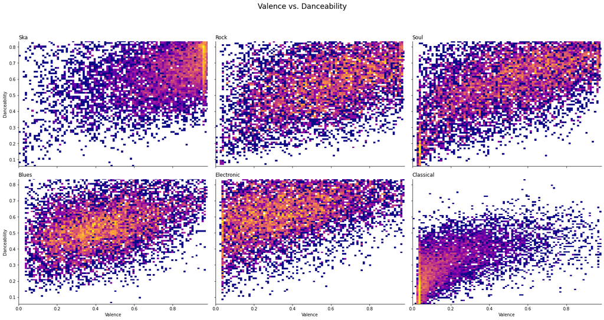

```python
fig, ax = plt.subplots(2,3,figsize=(20,10),sharex=True,sharey=True)   # Setting up the subplots
plt.suptitle('Valence vs. Danceability',size='xx-large',y=1.05)   # Setting a title for the entire group of plots
plt.plasma()   # Setting the color palette
ax[0][0].hist2d(ska['valence'],ska['danceability'],bins=90,norm=colors.LogNorm())
ax[0][0].set_title('Ska',loc='left')
ax[0][0].set_ylabel('Danceability')
ax[0][0].spines['right'].set_visible(False)   # Removes the right spine on the graph
ax[0][0].spines['top'].set_visible(False)   # Removes the top spine on the graph

ax[0][1].hist2d(rock['valence'],rock['danceability'],bins=90,norm=colors.LogNorm())
ax[0][1].set_title('Rock',loc='left')
ax[0][1].spines['right'].set_visible(False)
ax[0][1].spines['top'].set_visible(False)

ax[0][2].hist2d(soul['valence'],soul['danceability'],bins=90,norm=colors.LogNorm())
ax[0][2].set_title('Soul',loc='left')
ax[0][2].spines['right'].set_visible(False)
ax[0][2].spines['top'].set_visible(False)

ax[1][0].hist2d(blues['valence'],blues['danceability'],bins=90,norm=colors.LogNorm())
ax[1][0].set_title('Blues',loc='left')
ax[1][0].set_xlabel('Valence')
ax[1][0].set_ylabel('Danceability')
ax[1][0].spines['right'].set_visible(False)
ax[1][0].spines['top'].set_visible(False)

ax[1][1].hist2d(electronic['valence'],electronic['danceability'],bins=90,norm=colors.LogNorm())
ax[1][1].set_title('Electronic',loc='left')
ax[1][1].set_xlabel('Valence')
ax[1][1].spines['right'].set_visible(False)
ax[1][1].spines['top'].set_visible(False)

ax[1][2].hist2d(classical['valence'],classical['danceability'],bins=90,norm=colors.LogNorm())
ax[1][2].set_title('Classical',loc='left')
ax[1][2].set_xlabel('Valence')
ax[1][2].spines['right'].set_visible(False)
ax[1][2].spines['top'].set_visible(False)

plt.tight_layout()


# Prints the statistical properties of the two columns
newska = pd.merge(ska['valence'],ska['danceability'],left_index=True,right_index=True)
print("Table 2.1.1: Ska\n\n",newska.describe(),"\n")
print()
newcla = pd.merge(classical['valence'],classical['danceability'],left_index=True,right_index=True)
print("Table 2.1.2: Classical\n\n",newcla.describe(),"\n","\n","\n")
```

At a first glance, there does appear to be correlation between valence and dancability. For instance, Rock, Soul, Blues, and Electronic have similar distributions that are characterized by the positive and seemingly linear relationship between the most dense areas of the plots. The plot for Ska music does appear to have some positive correlation, but our argument for this genre is weakened by the extremely high density in the high values of both valence and danceability. As shown in Table 2.1.1, 75% of the data has at least a valence rating of 0.598 and at least a danceability rating of 0.526. This is a reasonable result because Ska music is generally upbeat and has origins being played in clubs. However, according to Table 2.1.2, the 75th percentile for Classical music only has valence and danceability ratings of 0.31 and 0.4 respectively. This coincides with the plot for Classical music, as most of the data below a danceability of 0.5, and it makes sense because it's generally lower in tempo and doesn't have a very strong beat. Despite the small variation between some of the plots, I have a great deal of confidence in an existent correlation between valence and danceability because of the consistent shape of the distributions.

Next, I looked at the relationship between valence and energy ratings. In this study, energy is a rating from 0.0 to 1.0, and it measures the perceptual intensity of the music.<sub>1</sub>

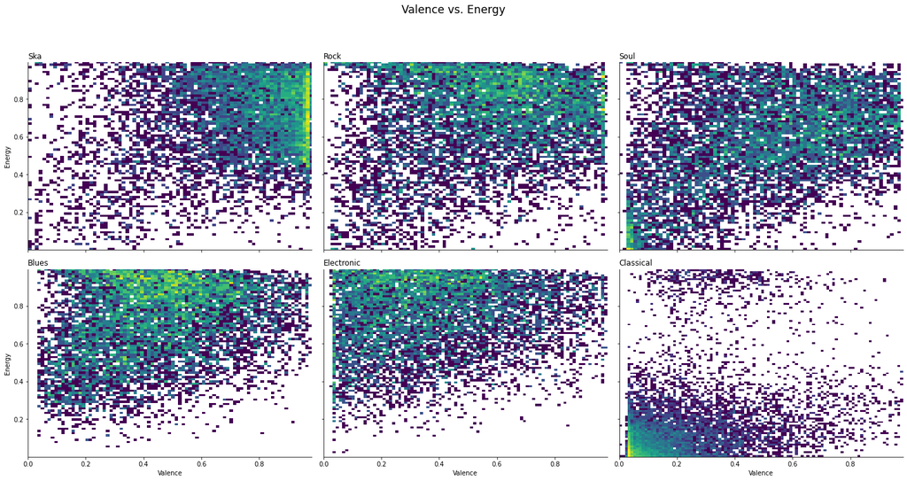

```python
fig, ax = plt.subplots(2,3,figsize=(20,10),sharex=True,sharey=True)
plt.suptitle('Valence vs. Energy',size='xx-large',y=1.05)
plt.viridis()
ax[0][0].hist2d(ska['valence'],ska['energy'],bins=80,norm=colors.LogNorm())
ax[0][0].set_title('Ska',loc='left')
ax[0][0].set_ylabel('Energy')
ax[0][0].spines['right'].set_visible(False)
ax[0][0].spines['top'].set_visible(False)

ax[0][1].hist2d(rock['valence'],rock['energy'],bins=80,norm=colors.LogNorm())
ax[0][1].set_title('Rock',loc='left')
ax[0][1].spines['right'].set_visible(False)
ax[0][1].spines['top'].set_visible(False)

ax[0][2].hist2d(soul['valence'],soul['energy'],bins=80,norm=colors.LogNorm())
ax[0][2].set_title('Soul',loc='left')
ax[0][2].spines['right'].set_visible(False)
ax[0][2].spines['top'].set_visible(False)

ax[1][0].hist2d(blues['valence'],blues['energy'],bins=80,norm=colors.LogNorm())
ax[1][0].set_title('Blues',loc='left')
ax[1][0].set_xlabel('Valence')
ax[1][0].set_ylabel('Energy')
ax[1][0].spines['right'].set_visible(False)
ax[1][0].spines['top'].set_visible(False)

ax[1][1].hist2d(electronic['valence'],electronic['energy'],bins=90,norm=colors.LogNorm())
ax[1][1].set_title('Electronic',loc='left')
ax[1][1].set_xlabel('Valence')
ax[1][1].spines['right'].set_visible(False)
ax[1][1].spines['top'].set_visible(False)

ax[1][2].hist2d(classical['valence'],classical['energy'],bins=100,norm=colors.LogNorm())
ax[1][2].set_title('Classical',loc='left')
ax[1][2].set_xlabel('Valence')
ax[1][2].spines['right'].set_visible(False)
ax[1][2].spines['top'].set_visible(False)

plt.tight_layout()
```

In the plot above, there is clear variation between the valence and energy trends within each genre. With Blues and Electronic music, there is an interesting distribution with a large density of songs having high energy and low valence. This makes sense because Blues music typically comes from a place of shortcomings in life, which explains the majority of data having a valence of below 0.5. In the case of Electronic music, this is a reasonable observation because it's known to be played at clubs and parties, which implies a higher energy level despite the valence level. On the other hand, for the Electronic songs with lower energy, it makes sense that it has a lower valence level since the low-energy songs tend to be more sad or mellow, leading to a lower valence level. Moreover, Ska and Rock music have similar distributions where a considerable amount of the songs are high in valence and energy. This can be explained by the fact that they are typically very energetic and upbeat songs. Rock music, which is known for having a broad spectrum of happy, angry, and angsty songs, has a higher density of songs spread evenly along the valence scale with very high energy. For Soul music, there is a weak positive linear correlation of songs along both scales, with much of the data having similar valence and energy values. Finally, with Classical music, there is a drastically different distribution with most of the data having below a 0.4 on both scales. As discussed in the previous model, there is a very high density of songs with low valences, and those songs tend to be very soft and often sad songs. Given these tendencies, it makes sense for an extensive amount of Classical songs to have lower energy as well. There is, however, an interesting pocket of Classical songs with low-to-mid level valences and energies above 0.8. This can be explained the group of songs that are more angry and emotionally strong than the majority of songs in the genre. All in all, I don't have confidence in a strong correlation between valence and energy of a song because of the vast differences between the distributions.

Moving forward, I studied the relationship between valence and loudness. For the purposes of this study, loudness is measured as the overall volume of the songs in decibels ranging from -60.0 to 0.0 dB.<sub>1</sub>

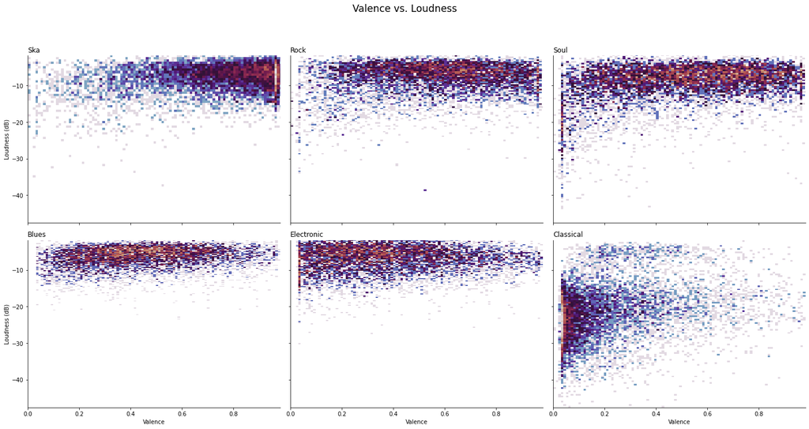

```python
fig, ax = plt.subplots(2,3,figsize=(20,10),sharex=True,sharey=True)
plt.suptitle('Valence vs. Loudness',size='xx-large',y=1.05)
plt.set_cmap('twilight')
ax[0][0].hist2d(ska['valence'],ska['loudness'],bins=100,norm=colors.LogNorm())
ax[0][0].set_title('Ska',loc='left')
ax[0][0].set_ylabel('Loudness (dB)')
ax[0][0].spines['right'].set_visible(False)
ax[0][0].spines['top'].set_visible(False)

ax[0][1].hist2d(rock['valence'],rock['loudness'],bins=100,norm=colors.LogNorm())
ax[0][1].set_title('Rock',loc='left')
ax[0][1].spines['right'].set_visible(False)
ax[0][1].spines['top'].set_visible(False)

ax[0][2].hist2d(soul['valence'],soul['loudness'],bins=100,norm=colors.LogNorm())
ax[0][2].set_title('Soul',loc='left')
ax[0][2].spines['right'].set_visible(False)
ax[0][2].spines['top'].set_visible(False)

ax[1][0].hist2d(blues['valence'],blues['loudness'],bins=100,norm=colors.LogNorm())
ax[1][0].set_title('Blues',loc='left')
ax[1][0].set_xlabel('Valence')
ax[1][0].set_ylabel('Loudness (dB)')
ax[1][0].spines['right'].set_visible(False)
ax[1][0].spines['top'].set_visible(False)

ax[1][1].hist2d(electronic['valence'],electronic['loudness'],bins=100,norm=colors.LogNorm())
ax[1][1].set_title('Electronic',loc='left')
ax[1][1].set_xlabel('Valence')
ax[1][1].spines['right'].set_visible(False)
ax[1][1].spines['top'].set_visible(False)

ax[1][2].hist2d(classical['valence'],classical['loudness'],bins=100,norm=colors.LogNorm())
ax[1][2].set_title('Classical',loc='left')
ax[1][2].set_xlabel('Valence')
ax[1][2].spines['right'].set_visible(False)
ax[1][2].spines['top'].set_visible(False)

plt.tight_layout()
```

Despite the similarity of the distributions between each genre, I concluded right away that there is little to no correlation between valence and loudness. With the exception of Classical music, there is a fairly even distribution of songs along the valence levels, but most of the songs in each genre lies above the -15.0 dB level. In other words, no matter what a song's valence level is, it will most likely have a loudness level of above -15.0 dB. Classical music is a special case of this because classical music is much more diverse with dynamic (volume) levels than other genres of music are. This explains the significant variance in loudness levels. Hence, loudness has little to no correlation with valence.

Next, I attempted to find correlation between a song's valence level and tempo. In this study, tempo is defined as the overall speed or pace of a song that is measured in beats per minute (BPM).<sub>1</sub>

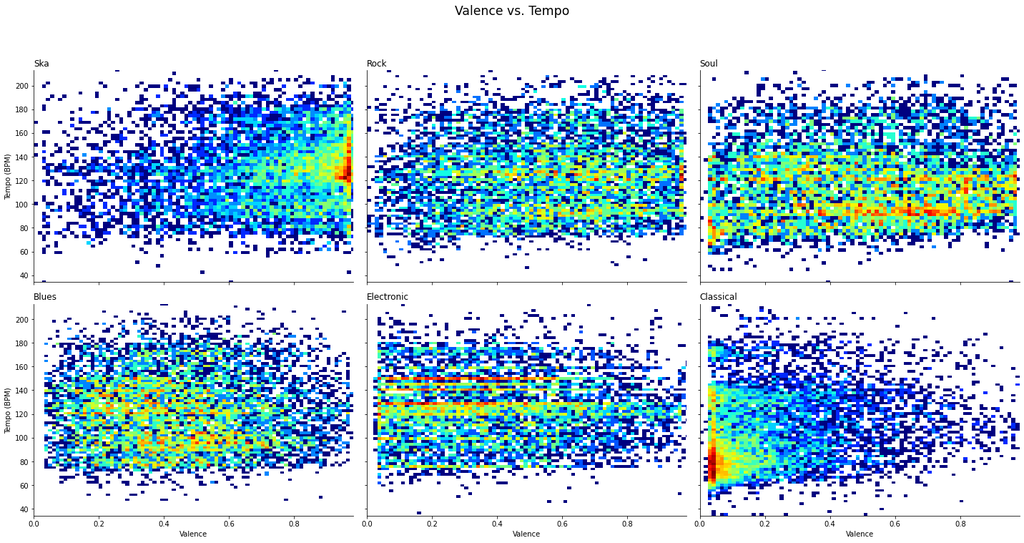

```python
fig, ax = plt.subplots(2,3,figsize=(20,10),sharex=True,sharey=True)
plt.suptitle('Valence vs. Tempo',size='xx-large',y=1.05)
plt.set_cmap('jet')
ax[0][0].hist2d(ska['valence'],ska['tempo'],bins=80,norm=colors.LogNorm())
ax[0][0].set_ylabel('Tempo (BPM)')
ax[0][0].set_title('Ska',loc='left')
ax[0][0].spines['right'].set_visible(False)
ax[0][0].spines['top'].set_visible(False)

ax[0][1].hist2d(rock['valence'],rock['tempo'],bins=80,norm=colors.LogNorm())
ax[0][1].set_title('Rock',loc='left')
ax[0][1].spines['right'].set_visible(False)
ax[0][1].spines['top'].set_visible(False)

ax[0][2].hist2d(soul['valence'],soul['tempo'],bins=80,norm=colors.LogNorm())
ax[0][2].set_title('Soul',loc='left')
ax[0][2].spines['right'].set_visible(False)
ax[0][2].spines['top'].set_visible(False)

ax[1][0].hist2d(blues['valence'],blues['tempo'],bins=80,norm=colors.LogNorm())
ax[1][0].set_title('Blues',loc='left')
ax[1][0].set_xlabel('Valence')
ax[1][0].set_ylabel('Tempo (BPM)')
ax[1][0].spines['right'].set_visible(False)
ax[1][0].spines['top'].set_visible(False)

ax[1][1].hist2d(electronic['valence'],electronic['tempo'],bins=80,norm=colors.LogNorm())
ax[1][1].set_title('Electronic',loc='left')
ax[1][1].set_xlabel('Valence')
ax[1][1].spines['right'].set_visible(False)
ax[1][1].spines['top'].set_visible(False)

ax[1][2].hist2d(classical['valence'],classical['tempo'],bins=80,norm=colors.LogNorm())
ax[1][2].set_title('Classical',loc='left')
ax[1][2].set_xlabel('Valence')
ax[1][2].spines['right'].set_visible(False)
ax[1][2].spines['top'].set_visible(False)

plt.tight_layout()
```

In the case of Rock, Soul, Blues, and Electronic music, there appears to be no specific correlation between tempo and valence. The high-density area of these plots centralize between 100 and 140bpm and span over nearly the whole valence scale. With Classical music, the high density of low-valence songs corresponds with a high density in low-tempo songs. This is shown with the red/orange area of the Classical music plot. Also, this is a reasonable result because low-tempo songs are most likely to be softer, sadder songs. With Ska music, there is a very high density of songs with a valence of 0.9 or higher, and these songs have tempos between 120 and 140bpm. This makes sense as Ska is generally upbeat, and the tempos with the highest densities correspond with the high danceability ratings (from Table 2.1.1). Thus, judging from the majority of the plots, there doesn't appear to be very much correlation between valence and tempo.

I continued my research with a study of the possible relationship between valence and mode. In this context, the mode of the song is defined as either "Major" or "Minor". To analyze these relationships, I used violin plots to utilize their ability to show densities of valences within each mode.

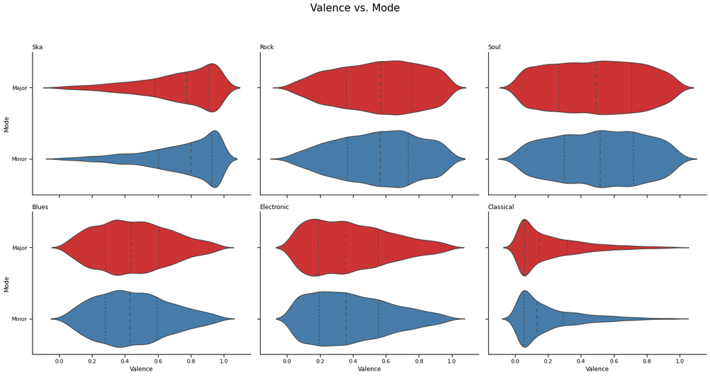

```python
import seaborn as sns
sns.set_context('notebook')
fig, ax = plt.subplots(2,3,figsize=(20,10),sharex=True,sharey=True)
plt.suptitle('Valence vs. Mode',size='xx-large',y=1.05)
sns.violinplot(x='valence',y='mode',data=ska,ax=ax[0][0],inner='quartiles',palette='Set1')
ax[0][0].set_ylabel('Mode')
ax[0][0].set_xlabel('')
ax[0][0].set_title('Ska',loc='left')
ax[0][0].spines['right'].set_visible(False)
ax[0][0].spines['top'].set_visible(False)

sns.violinplot(x='valence',y='mode',data=rock,ax=ax[0][1],inner='quartiles',palette='Set1')
ax[0][1].set_title('Rock',loc='left')
ax[0][1].set_xlabel('')
ax[0][1].set_ylabel('')
ax[0][1].spines['right'].set_visible(False)
ax[0][1].spines['top'].set_visible(False)

sns.violinplot(x='valence',y='mode',data=soul,ax=ax[0][2],inner='quartiles',palette='Set1')
ax[0][2].set_title('Soul',loc='left')
ax[0][2].set_xlabel('')
ax[0][2].set_ylabel('')
ax[0][2].spines['right'].set_visible(False)
ax[0][2].spines['top'].set_visible(False)

sns.violinplot(x='valence',y='mode',data=blues,ax=ax[1][0],inner='quartiles',palette='Set1')
ax[1][0].set_title('Blues',loc='left')
ax[1][0].set_xlabel('Valence')
ax[1][0].set_ylabel('Mode')
ax[1][0].spines['right'].set_visible(False)
ax[1][0].spines['top'].set_visible(False)

sns.violinplot(x='valence',y='mode',data=electronic,ax=ax[1][1],inner='quartiles',palette='Set1')
ax[1][1].set_title('Electronic',loc='left')
ax[1][1].set_xlabel('Valence')
ax[1][1].set_ylabel('')
ax[1][1].spines['right'].set_visible(False)
ax[1][1].spines['top'].set_visible(False)

sns.violinplot(x='valence',y='mode',data=classical,ax=ax[1][2],inner='quartiles',palette='Set1')
ax[1][2].set_title('Classical',loc='left')
ax[1][2].set_xlabel('Valence')
ax[1][2].set_ylabel('')
ax[1][2].spines['right'].set_visible(False)
ax[1][2].spines['top'].set_visible(False)

plt.tight_layout()
```

As seen in the model above, the distributions for major songs are nearly identical to their respective distribution for minor songs. This simply means that, judging by this data, mode does not have any correlation with valence.

Similar to the model above, I used violin plots to find the correlation between valence and the musical key of the piece. Key, for those without knowledge of musical terminology, describes which notes can be used in the song (unless stated otherwise in the music).

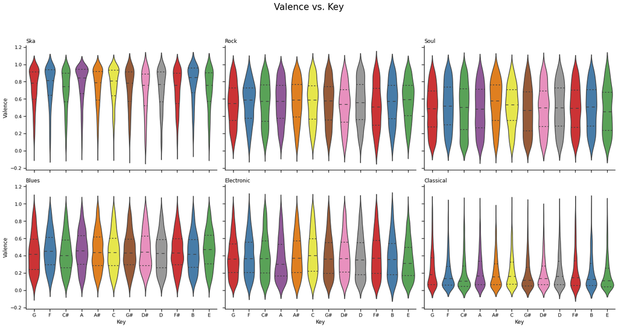

```python
fig, ax = plt.subplots(2,3,figsize=(20,10),sharex=True,sharey=True)
plt.suptitle('Valence vs. Key',size='xx-large',y=1.05)
sns.violinplot(x='key',y='valence',data=ska,ax=ax[0][0],inner='quartiles',palette='Set1')
ax[0][0].set_ylabel('Valence')
ax[0][0].set_xlabel('')
ax[0][0].set_title('Ska',loc='left')
ax[0][0].spines['right'].set_visible(False)
ax[0][0].spines['top'].set_visible(False)

sns.violinplot(x='key',y='valence',data=rock,ax=ax[0][1],inner='quartiles',palette='Set1')
ax[0][1].set_title('Rock',loc='left')
ax[0][1].set_xlabel('')
ax[0][1].set_ylabel('')
ax[0][1].spines['right'].set_visible(False)
ax[0][1].spines['top'].set_visible(False)

sns.violinplot(x='key',y='valence',data=soul,ax=ax[0][2],inner='quartiles',palette='Set1')
ax[0][2].set_title('Soul',loc='left')
ax[0][2].set_xlabel('')
ax[0][2].set_ylabel('')
ax[0][2].spines['right'].set_visible(False)
ax[0][2].spines['top'].set_visible(False)

sns.violinplot(x='key',y='valence',data=blues,ax=ax[1][0],inner='quartiles',palette='Set1')
ax[1][0].set_title('Blues',loc='left')
ax[1][0].set_xlabel('Key')
ax[1][0].set_ylabel('Valence')
ax[1][0].spines['right'].set_visible(False)
ax[1][0].spines['top'].set_visible(False)

sns.violinplot(x='key',y='valence',data=electronic,ax=ax[1][1],inner='quartiles',palette='Set1')
ax[1][1].set_title('Electronic',loc='left')
ax[1][1].set_xlabel('Key')
ax[1][1].set_ylabel('')
ax[1][1].spines['right'].set_visible(False)
ax[1][1].spines['top'].set_visible(False)

sns.violinplot(x='key',y='valence',data=classical,ax=ax[1][2],inner='quartiles',palette='Set1')
ax[1][2].set_title('Classical',loc='left')
ax[1][2].set_xlabel('Key')
ax[1][2].set_ylabel('')
ax[1][2].spines['right'].set_visible(False)
ax[1][2].spines['top'].set_visible(False)

plt.tight_layout()
```

It seems that this is a similar result to the model comparing valence and mode. If there was a correlation between valence and key, there would be high densities in different valence levels within each key. Since the distribution for each key is impeccably similar to the others within each genre, I conclude that there is no correlation between a song's valence level and key.

To conclude, danceability is the only song attribute that has any correlation to valence. This will be discussed in greater detail in section 3.

##### **2.2. Analyzing Valence Distributions for Each Genre**

Now, we will look at valence levels across every genre to determine if some genres tend to be "happier" than others.

```
                               Table 2.2.1: Percentile Chart

       A Capella-   30th Percentile: 0.137;   60th Percentile: 0.350;   90th Percentile: 0.716
         Country-   30th Percentile: 0.392;   60th Percentile: 0.599;   90th Percentile: 0.840
           Dance-   30th Percentile: 0.374;   60th Percentile: 0.576;   90th Percentile: 0.835
     Alternative-   30th Percentile: 0.316;   60th Percentile: 0.501;   90th Percentile: 0.755
      Electronic-   30th Percentile: 0.223;   60th Percentile: 0.429;   90th Percentile: 0.738
           Anime-   30th Percentile: 0.316;   60th Percentile: 0.501;   90th Percentile: 0.755
            Folk-   30th Percentile: 0.275;   60th Percentile: 0.491;   90th Percentile: 0.795
           Blues-   30th Percentile: 0.316;   60th Percentile: 0.501;   90th Percentile: 0.755
           Movie-   30th Percentile: 0.192;   60th Percentile: 0.446;   90th Percentile: 0.796
           Opera-   30th Percentile: 0.117;   60th Percentile: 0.311;   90th Percentile: 0.677
         Hip-Hop-   30th Percentile: 0.535;   60th Percentile: 0.706;   90th Percentile: 0.878
           Indie-   30th Percentile: 0.335;   60th Percentile: 0.569;   90th Percentile: 0.854
            Jazz-   30th Percentile: 0.337;   60th Percentile: 0.568;   90th Percentile: 0.814
Children’s Music-   30th Percentile: 0.316;   60th Percentile: 0.501;   90th Percentile: 0.755
             R&B-   30th Percentile: 0.395;   60th Percentile: 0.641;   90th Percentile: 0.880
       Classical-   30th Percentile: 0.069;   60th Percentile: 0.195;   90th Percentile: 0.516
             Rap-   30th Percentile: 0.430;   60th Percentile: 0.634;   90th Percentile: 0.856
          Comedy-   30th Percentile: 0.289;   60th Percentile: 0.468;   90th Percentile: 0.689
          Reggae-   30th Percentile: 0.667;   60th Percentile: 0.812;   90th Percentile: 0.949
             Pop-   30th Percentile: 0.387;   60th Percentile: 0.633;   90th Percentile: 0.885
            Rock-   30th Percentile: 0.407;   60th Percentile: 0.642;   90th Percentile: 0.883
       Reggaeton-   30th Percentile: 0.623;   60th Percentile: 0.789;   90th Percentile: 0.935
      Soundtrack-   30th Percentile: 0.087;   60th Percentile: 0.358;   90th Percentile: 0.771
            Soul-   30th Percentile: 0.324;   60th Percentile: 0.585;   90th Percentile: 0.856
             Ska-   30th Percentile: 0.646;   60th Percentile: 0.848;   90th Percentile: 0.964
           World-   30th Percentile: 0.266;   60th Percentile: 0.496;   90th Percentile: 0.798



                                  Table 2.2.2: Ranked Percentiles

                Rank        30th Percentile      60th Percentile      90th Percentile
                ______________________________________________________________________
                   1         Reggae:0.667            Ska:0.848            Ska:0.964
                   2            Ska:0.646         Reggae:0.812         Reggae:0.949
                   3      Reggaeton:0.623      Reggaeton:0.789      Reggaeton:0.935
                   4        Hip-Hop:0.535        Hip-Hop:0.706            Pop:0.885
                   5            Rap:0.430           Rock:0.642           Rock:0.883
                 ...            ...                  ...                        ...
                  22          Movie:0.192     Electronic:0.429     Electronic:0.738
                  23      A Capella:0.137     Soundtrack:0.358      A Capella:0.716
                  24          Opera:0.117      A Capella:0.350         Comedy:0.689
                  25     Soundtrack:0.087          Opera:0.311          Opera:0.677
                  26      Classical:0.069      Classical:0.195      Classical:0.516
```

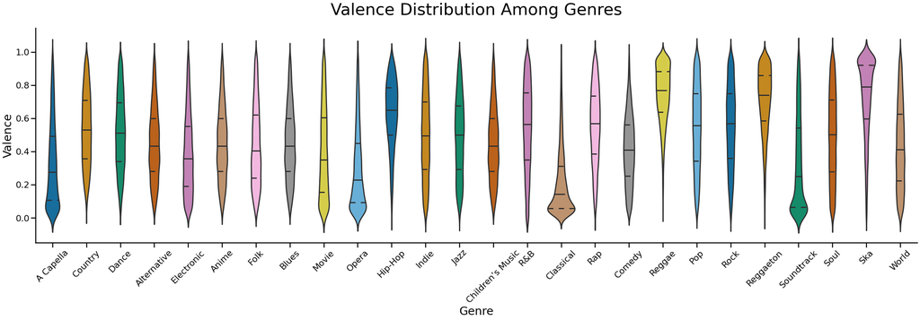

```python
plt.figure(figsize=(40,10)) # Sets figure size
sns.set_context('poster') # Sets the viewing context of the plot

pal = ["#9b59b6", "#3498db", "#95a5a6", "#e74c3c", "#34495e", "#2ecc71"] # Custom color palette

sns.violinplot(x='genre',y='valence',data=full_data,inner='quartiles',palette='colorblind')
plt.title('Valence Distribution Among Genres',size='xx-large',y=1.05) # kwargs change the size and position of the Title
plt.xlabel('Genre',size='large')
plt.xticks(rotation=45) # Rotates the x tick labels by 45 degrees
plt.ylabel('Valence',size='large')
sns.despine()




valences = pd.DataFrame(full_data[full_data['genre'] == genres[0]]['valence']) # Creates a DataFrame with each genre's valences in separate columns

for g in range(1,26):
    temp = pd.DataFrame(full_data[full_data['genre'] == genres[g]]['valence']) # Isolate the valence values for each genre
    valences = pd.concat([valences,temp],join='outer',axis=1,ignore_index=True) # Adds that genre's valences onto the DataFrame

valences.columns = genres # changing the names of the columns to the columns' respective genres

pctile_30 = {} # 30th Percentile Dictionary
pctile_60 = {} # 60th Percentile Dictionary
pctile_90 = {} # 90th Percentile Dictionary
for g in genres:
    # Add the percentile value for a genre in its respective dictionary
    pctile_30[g] = float(np.nanpercentile(valences[g],30))
    pctile_60[g] = float(np.nanpercentile(valences[g],60))
    pctile_90[g] = float(np.nanpercentile(valences[g],90))

print("\n\n\n{:>60}\n".format("Table 2.2.1: Percentile Chart"))
for g in genres:
    print("{:>16}-   30th Percentile: {:.3f};   60th Percentile: {:.3f};   90th Percentile: {:.3f}".format(g,pctile_30[g],pctile_60[g],pctile_90[g]))




# Sorting each percentile dictionary to show the top 5 and bottom 5 genres for each percentile value

ranked_30 = sorted(pctile_30.items(), key = lambda x: x[1], reverse = True)
ranked_60 = sorted(pctile_60.items(), key = lambda x: x[1], reverse = True)
ranked_90 = sorted(pctile_90.items(), key = lambda x: x[1], reverse = True)

print("\n\n\n{:>65}\n".format("Table 2.2.2: Ranked Percentiles"))
print("{:>20}        {:15}      {:15}      {:15}".format("Rank","30th Percentile","60th Percentile","90th Percentile"))
print('{}{}'.format(' '*16,'_'*70))
for i in range(26):
    if i < 5:
        print("{:>20}     {:>10}:{:.3f}     {:>10}:{:.3f}     {:>10}:{:.3f}".format(i+1,ranked_30[i][0],ranked_30[i][1],ranked_60[i][0],ranked_60[i][1],ranked_90[i][0],ranked_90[i][1]))
    elif i == 5:
        print("{:>20}     {:>10}     {:>16}     {:>22}".format('...','...','...','...'))
    elif (i > 20):
        print("{:>20}     {:>10}:{:.3f}     {:>10}:{:.3f}     {:>10}:{:.3f}".format(i+1,ranked_30[i][0],ranked_30[i][1],ranked_60[i][0],ranked_60[i][1],ranked_90[i][0],ranked_90[i][1]))

print('\n\n\n')
```

As shown in the plot above, there are a few obvious examples of genres with a skewed valence distribution. For example, the distribution for Ska music has a very high density at the very top of the valence scale, while Opera and A Capella music has a high density of songs with a valence that is close to 0.0. Looking Table 2.2.2, some important results to note are the 30th Percentile values for Reggae, Ska, and Reggaeton, which are 0.667, 0.646, and 0.623 respectively. These results imply that 70% of the valence values for these genres are above 0.667, 0.646, and 0.623, so Reggae, Ska, and Reggaeton can be classified as "Happy" genres. Additionally, Table 2.2.2 shows that the 90% of valence values for Comedy, Opera, and Classical music are under 0.689, 0.677, and 0.516 respectively. With these results, I can classify Comedy, Opera, and Classical music as "Unhappy" genres.

It seems counterintuitive for Comedy to be classified as an "Unhappy" genre, but this is due to the way valence is determined. Songs with high valence have characteristics like sounding cheerful, joyous, euphoric, etc.<sub>1</sub> In the case of Comedy, many songs are parodies of other songs. Despite the changed lyrics being funny, the song itself might sound as angry or sad as the original song. If the song isn't a parody, then it is likely to be a Stand-Up routine recorded and put into a Spotify album. "Songs" such as these show very little of what is characteristic of a song with high valence due to their spoken-word nature. In general, valence isn't determined by the meanings of the lyrics or the story behind the songs, but it's determined simply by how the song sounds.

Therefore, I can confidently say that, yes, there are genres that tend to be much happier than others. This will be discussed more in section 3.

##### **2.3. Finding Correlation Between Popularity and Valence**

To answer my final question, I looked at the data for valence plotted against the data for popularity. Popularity is defined in this context by a rating between 0 and 100.

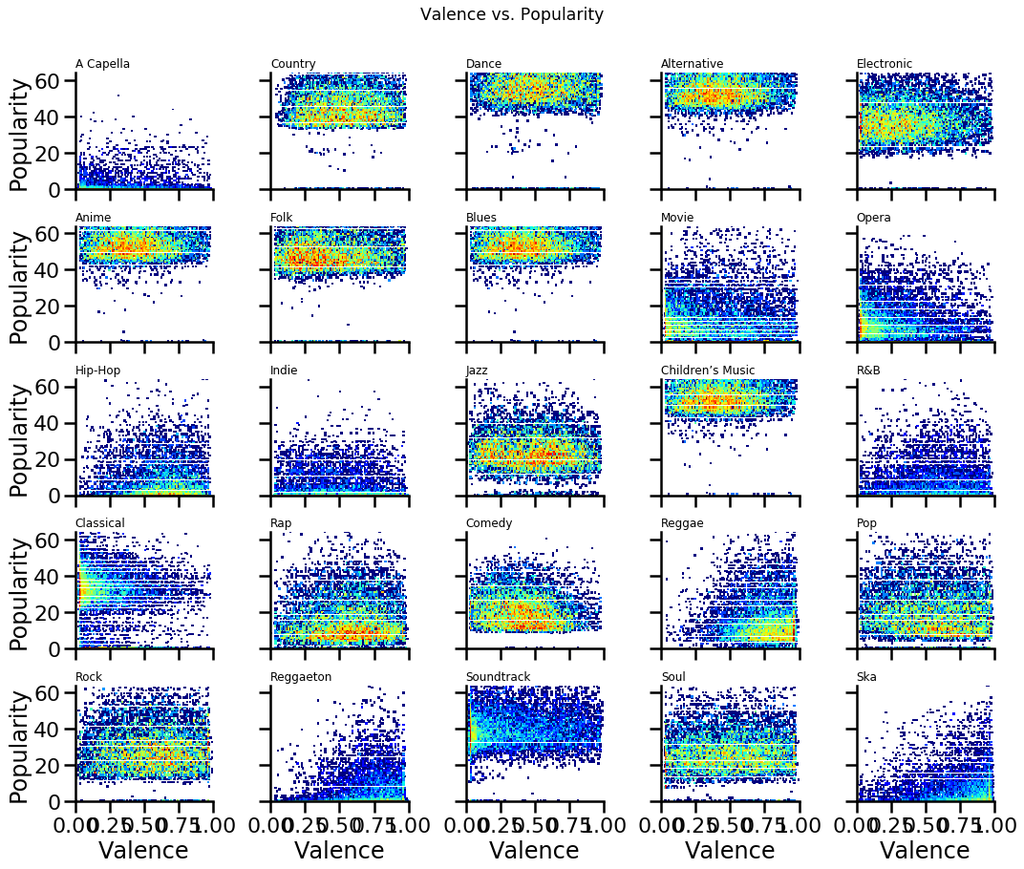

```python
fig, ax = plt.subplots(5,5,figsize=(15,12),sharex=True,sharey=True)
sns.reset_defaults()
plt.suptitle('Valence vs. Popularity',size='xx-large',y=1.05) # Sets title for the group of plots
plt.set_cmap('jet') # Sets colormap

gcount = 0 # Counter to access the genres in the list of genres
for i in range(5):
    for j in range(5):
        x = full_data[full_data['genre']==genres[gcount]]['valence']
        y = full_data[full_data['genre']==genres[gcount]]['popularity']
        ax[i][j].hist2d(x, y,bins=100,norm=colors.LogNorm())
        ax[i][j].set_title(genres[gcount],loc='left')
        sns.despine() # Takes the right and top spines off the plots
        gcount += 1

        if j == 0:
            ax[i][j].set_ylabel('Popularity') # Setting y axis labels along the left hand side

        if i == 4:
            ax[i][j].set_xlabel('Valence') # Setting x axis labels along the bottom

plt.tight_layout()
```

As shown by the plot above, there's a variety of distribution trends between the different genres of music. In general, the popularity level for each genre tends to be horizontal across the valence scale, with the higher densities of songs gravitating towards a valence of 0.5 in some cases. The high-density areas of the plots are fairly flat and horizontally linear, showing that a high density of songs can span across a wide valence range despite being around the same popularity level. Therefore, given the variance between each of the genres' plots, I conclude that there is no correlation between valence of a song and its popularity.

#### **3. Results and Discussion**

In Section 2.1, I concluded that there is only a strong correlation between valence and danceability. Upon studying the relationship between valence and key, mode, energy, tempo, and loudness, there didn't appear to be a strong enough correlation to answer my question. It's quite reasonable to conclude that valence and danceability are correlated because when people dance, they tend to be happy! Songs that are upbeat and positive have an effect on people that not only put them in a better mood, but make them want to get up and move. Hence, it makes sense for this correlation to exist.

In Section 2.2, I concluded that there, in fact, are genres of music that have a notably higher valence than others. We noted that while Ska, Reggae, and Reggaeton music have very high valence levels as entire genres, Classical, Comedy, and Opera tend to have very low valence levels. This result does make sense because genres with high valence levels tend to have origins of trying to lift people up, while genres with lower valence levels tend to explore the range of emotions much more in-depth.

In Section 2.3, I came to the conclusion that there is no strong or direct correlation between valence and popularity of a song. Most of the plots had a great deal of variance between them, and those that were similar didn't have any kind of meaningful trend to them. Therefore, valence and popularity of a song do not have any meaningful correlation between them.

#### **4. References**

1. Get Audio Features for a Track. (n.d.). Retrieved December 2, 2019, from https://developer.spotify.com/documentation/web-api/reference/tracks/get-audio-features/. </p>
1. Hamidani, Z. (2019, July 23). Spotify Tracks DB. Retrieved December 2, 2019, from https://www.kaggle.com/zaheenhamidani/ultimate-spotify-tracks-db. </p>